# Final_Project

Step 0: Load the packages

Step 1: Read in the data and Get the node and edge attributes In the step, we select the data from HIV Transmission Network Metastudy Project.

```r
DF<- read.dta(file = "/Users/chenxiliu/Desktop/untitled\ folder\ 2/CS567/HW2/ICPSR_22140/DS0002/22140-0002-Data.dta")
DF1<- DF
##order the data by id1 and id2
DF<- DF[order(DF$id1,DF$id2),]
DF1<- na.omit(DF[,c(2:3,6)])
## Get the id list
node_list<- unique(c(DF$id1))
edge_list<- unique(na.omit(DF[,c(2:3,6)]))
edge_list$edge_type<- row.names(edge_list)
edge_list<- na.omit(edge_list)

## Get node attribte dataframe
n<- length(colnames(DF))
attribute_list<- seq(1, n, by = 1)
id1_attribute_list<- attribute_list[grepl("1",colnames(DF))]
id2_attribute_list<- attribute_list[grepl("2",colnames(DF))]
attribute_name_list<- gsub("1", "", colnames(DF)[grepl("1",colnames(DF))])
id1_attribute<- DF[,id1_attribute_list]
id2_attribute<- DF[,id2_attribute_list]
names(id1_attribute)<- attribute_name_list
names(id2_attribute)<- attribute_name_list
node_attribute_data<- rbind(id1_attribute, id2_attribute)
node_attribute_data<- node_attribute_data[,c(1,8,10,11,25,26,28,35)]
node_attribute_data$index<- as.numeric(rownames(node_attribute_data))
node_attribute_data<- node_attribute_data[order(node_attribute_data$index),]

## Get edge attribute dataframe
edge_attribute_list<- seq(1, n, by = 1)
edge_attribute_list<- edge_attribute_list[!as.logical(grepl("1",colnames(DF))+grepl("2",colnames(DF)))]
edge_attribute_data<- DF[,edge_attribute_list]
DF1<- na.omit(DF[,c(2:3, 6)])
```

Step 2: Do the RDS sampling

2.1 Sample overall data without any attribute In the step, we will do the sampling based on different seeds to identify various “sample tree”. Additionally, we will do sampling based on the attribute of the edges to find out the “sample tree” based on the kind of edge attribute

```r
##Over all sampling
sample_size<- 10000
sample_seed<- sample(node_list,1)
sample_seed<- 2
sample_data<- data.frame("id1" = NA, "id2" = NA, "edge_type" = NA)
wave_flow<-list()
wave_flow[["Seed"]]<- sample_seed
current_wave<- c(sample_seed)
wave_edge<-list()
current_size<- 0
wave_count<- 0
while (1)
{
  wave_count<- wave_count +1
  #wave_edge[[paste0("Wave", sep = "_", wave_count)]]<-  c((edge_list[edge_list$id1 == current_wave,]$rid))
  temp1<- c()
  for (i in 1:length(current_wave))
  {
    temp2<- as.vector(edge_list[edge_list$id1 == current_wave[i],]$id2)
    if(length(temp2) != 0)
    {
      for (j in 1:length(temp2))
      {
        temp4<- DF1[(DF1$id1 == current_wave[i]) & (DF1$id2 == temp2[j]),]$tietype[1]

        temp3<- data.frame(current_wave[i], temp2[j], temp4)
        names(temp3)<- c("id1", "id2", "edge_type")
        sample_data<- rbind(sample_data, temp3)
      }
      temp1<- c(temp1, temp2)
    }

  }
  current_wave<- temp1
  wave_flow[[paste0("Wave", sep = "_", wave_count)]]<- current_wave
  current_size<- current_size + length(current_wave)

  #print(current_wave)
  #print(wave_flow)

  if(current_size>= sample_size | wave_count>=3)
    break
}

sample_data<- na.omit(sample_data)
#sample_data<- sample_data[sample_data$edge_type != "OOD",]
```

2.2 Sample data based on the edge attribute In the step, we will do RDS based on the edge attributes. In the dataset, 4 kinds of edges have been defined: social connection, drug connection, sexual connection, and needle connection. We will sample the data based on the specified connections and figure out the structure of the network.

2.2.1 Sample data based on Social Connection (Wave = 3)

```r
## Social Connection
edge_list_social<- edge_list[edge_list$tietype == "Social",]
#sample_seed<- sample(node_list,1)
#sample_seed<- 2
sample_data_social<- data.frame("id1" = NA, "id2" = NA)
wave_flow<-list()
wave_flow[["Seed"]]<- sample_seed
current_wave<- c(sample_seed)
wave_edge<-list()
current_size<- 0
wave_count<- 0
while (1)
{
  wave_count<- wave_count +1
  #wave_edge[[paste0("Wave", sep = "_", wave_count)]]<-  c((edge_list[edge_list$id1 == current_wave,]$rid))
  temp1<- c()
  for (i in 1:length(current_wave))
  {
    temp2<- as.vector(edge_list_social[edge_list_social$id1 == current_wave[i],]$id2)
    if(length(temp2) != 0)
    {
      for (j in 1:length(temp2))
      {
        temp3<- data.frame(current_wave[i], temp2[j])
        names(temp3)<- c("id1", "id2")
        sample_data_social<- rbind(sample_data_social, temp3)
      }
      temp1<- c(temp1, temp2)
    }

  }
  current_wave<- temp1
  wave_flow[[paste0("Wave", sep = "_", wave_count)]]<- current_wave
  current_size<- current_size + length(current_wave)

  #print(current_wave)
  #print(wave_flow)

  if(current_size>= sample_size | wave_count>=3)
    break
}

sample_data_social<- na.omit(sample_data_social)
```

2.2.2 Sample data based on Drug Connection (Wave = 3)

```r
## Drug Connection
edge_list_drug<- edge_list[edge_list$tietype == "Drug",]
#sample_seed<- sample(node_list,1)
#sample_seed<- 2
sample_data_drug<- data.frame("id1" = NA, "id2" = NA)
wave_flow<-list()
wave_flow[["Seed"]]<- sample_seed
current_wave<- c(sample_seed)
wave_edge<-list()
current_size<- 0
wave_count<- 0
while (1)
{
  wave_count<- wave_count +1
  #wave_edge[[paste0("Wave", sep = "_", wave_count)]]<-  c((edge_list[edge_list$id1 == current_wave,]$rid))
  temp1<- c()
  for (i in 1:length(current_wave))
  {
    temp2<- as.vector(edge_list_drug[edge_list_drug$id1 == current_wave[i],]$id2)
    if(length(temp2) != 0)
    {
      for (j in 1:length(temp2))
      {
        temp3<- data.frame(current_wave[i], temp2[j])
        names(temp3)<- c("id1", "id2")
        sample_data_drug<- rbind(sample_data_drug, temp3)
      }
      temp1<- c(temp1, temp2)
    }

  }
  current_wave<- temp1
  wave_flow[[paste0("Wave", sep = "_", wave_count)]]<- current_wave
  current_size<- current_size + length(current_wave)

  #print(current_wave)
  #print(wave_flow)

  if(current_size>= sample_size | wave_count>=3)
    break
}

sample_data_drug<- na.omit(sample_data_drug)
```

2.2.3 Sample data based on Sexual Connection (Wave = 3)

```r
edge_list_sexual<- edge_list[edge_list$tietype == "Sexual",]
#sample_seed<- sample(node_list,1)
#sample_seed<- 2
sample_data_sexual<- data.frame("id1" = NA, "id2" = NA)
wave_flow<-list()
wave_flow[["Seed"]]<- sample_seed
current_wave<- c(sample_seed)
wave_edge<-list()
current_size<- 0
wave_count<- 0
while (1)
{
  wave_count<- wave_count +1
  #wave_edge[[paste0("Wave", sep = "_", wave_count)]]<-  c((edge_list[edge_list$id1 == current_wave,]$rid))
  temp1<- c()
  for (i in 1:length(current_wave))
  {
    temp2<- as.vector(edge_list_sexual[edge_list_sexual$id1 == current_wave[i],]$id2)
    if(length(temp2) != 0)
    {
      for (j in 1:length(temp2))
      {
        temp3<- data.frame(current_wave[i], temp2[j])
        names(temp3)<- c("id1", "id2")
        sample_data_sexual<- rbind(sample_data_sexual, temp3)
      }
      temp1<- c(temp1, temp2)
    }

  }
  current_wave<- temp1
  wave_flow[[paste0("Wave", sep = "_", wave_count)]]<- current_wave
  current_size<- current_size + length(current_wave)

  #print(current_wave)
  #print(wave_flow)

  if(current_size>= sample_size | wave_count>=3)
    break
}

sample_data_sexual<- na.omit(sample_data_sexual)
```

2.2.4 Sample based on Needle Connection (Wave = 3)

```r
edge_list_needle<- edge_list[edge_list$tietype == "Needle",]
#sample_seed<- sample(node_list,1)
#sample_seed<- 2
sample_data_needle<- data.frame("id1" = NA, "id2" = NA)
wave_flow<-list()
wave_flow[["Seed"]]<- sample_seed
current_wave<- c(sample_seed)
wave_edge<-list()
current_size<- 0
wave_count<- 0
while (1)
{
  wave_count<- wave_count +1
  #wave_edge[[paste0("Wave", sep = "_", wave_count)]]<-  c((edge_list[edge_list$id1 == current_wave,]$rid))
  temp1<- c()
  for (i in 1:length(current_wave))
  {
    temp2<- as.vector(edge_list_needle[edge_list_needle$id1 == current_wave[i],]$id2)
    if(length(temp2) != 0)
    {
      for (j in 1:length(temp2))
      {
        temp3<- data.frame(current_wave[i], temp2[j])
        names(temp3)<- c("id1", "id2")
        sample_data_needle<- rbind(sample_data_needle, temp3)
      }
      temp1<- c(temp1, temp2)
    }

  }
  current_wave<- temp1
  wave_flow[[paste0("Wave", sep = "_", wave_count)]]<- current_wave
  current_size<- current_size + length(current_wave)

  #print(current_wave)
  #print(wave_flow)

  if(current_size>= sample_size | wave_count>=3)
    break
}

sample_data_needle<- na.omit(sample_data_needle)
```

Step 3: Plot out the network and calculate the paprmeters of the sampled network like degree, betweenness, and closeness.

3.1 Plot out the sampled network based on various connection attributes, which can assist us to figure out the structure of the sampled network.

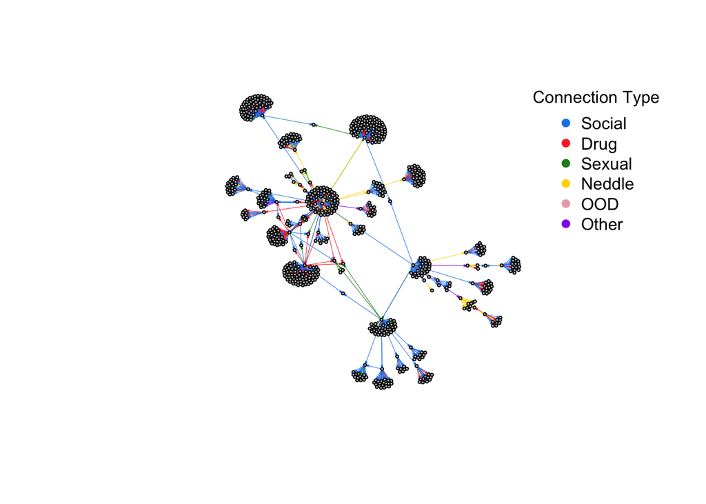

```r
#A<- sample_data
#sample_data<- A
sample_data<- unique(sample_data)
sample_data$color<- NA

sample_data[sample_data$edge_type == "Social",]$color<- "dodgerblue2"
sample_data[sample_data$edge_type == "Drug",]$color<- "firebrick1"
sample_data[sample_data$edge_type == "Sexual",]$color<- "gold1"
sample_data[sample_data$edge_type == "Needle",]$color<- "forestgreen"
sample_data[sample_data$edge_type == "OOD",]$color<- "purple2"
sample_data[sample_data$edge_type == "Other",]$color<- "pink2"
#sample_data<-sample_data[sort(sample_data$edge_type),]

matrix_overall<- as.matrix(sample_data[1:2])
class(matrix_overall)<- "character"
graph_overall<- graph.edgelist(matrix_overall, directed = T)
E(graph_overall)$color<- as.vector(sample_data$color)
plot(graph_overall, vertex.label = "", vertex.size = 2, vertex.color = "grey", edge.arrow.size = 0.1, edge.width = 0.5)
legend("topright", legend = c("Social", "Drug", "Sexual", "Neddle", "OOD", "Other"), col = levels(as.factor(as.vector(sample_data$color))), bty = "n", pch = 20, pt.cex = 1.5, cex = 1, title = "Connection Type")
```

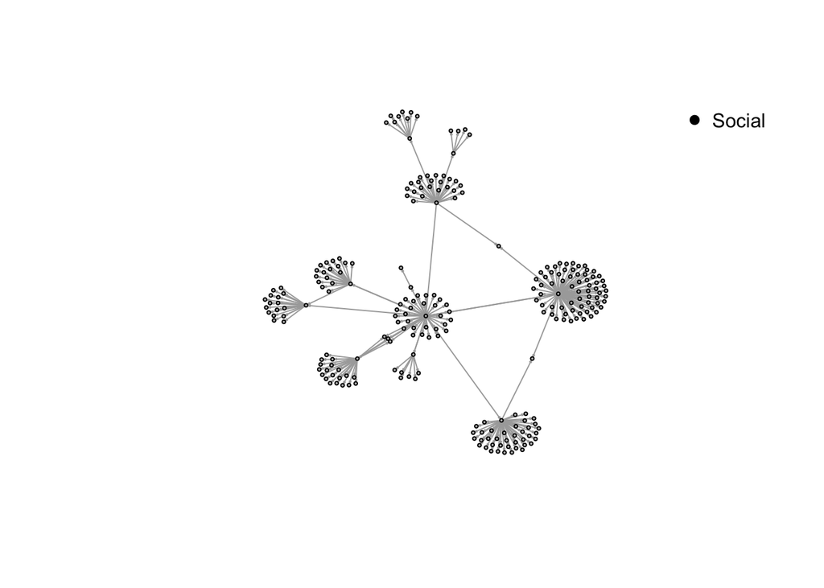

```r
matrix_social<- as.matrix(sample_data_social)
class(matrix_social)<- "character"
graph_social<- graph.edgelist(matrix_social, directed = T)
plot(graph_social, vertex.label = "", vertex.size = 2, vertex.color = "grey", edge.arrow.size = 0.1)
legend("topright", legend = "Social", bty = "n", pch = 20, pt.cex = 1.5, cex = 1)
```

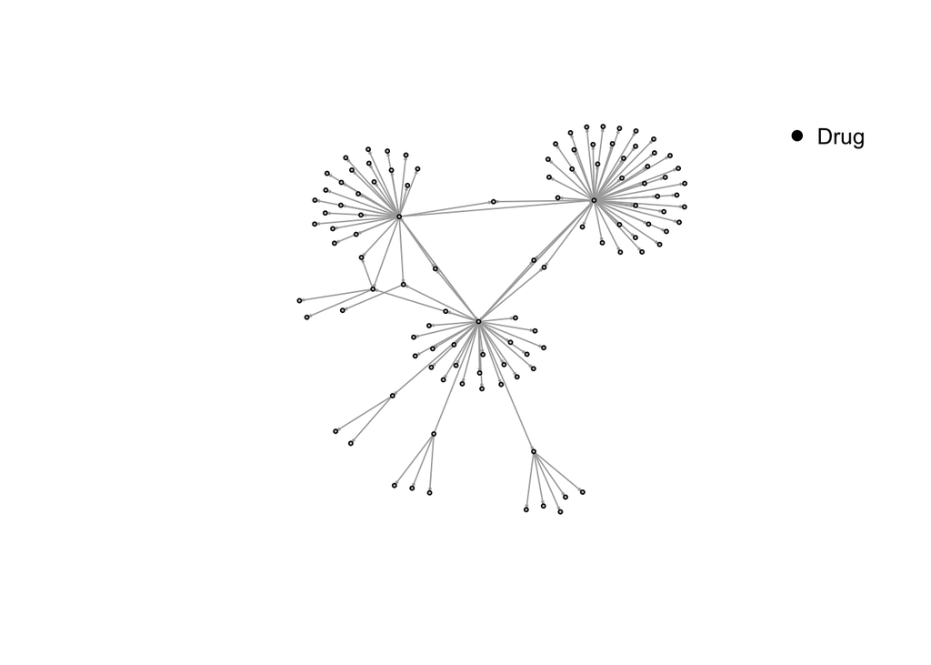

```r
matrix_drug<- as.matrix(sample_data_drug)
class(matrix_drug)<- "character"
graph_drug<- graph.edgelist(matrix_drug, directed = T)
plot(graph_drug, vertex.label = "", vertex.size = 2, vertex.color = "grey", edge.arrow.size = 0.1)
legend("topright", legend = "Drug", bty = "n", pch = 20, pt.cex = 1.5, cex = 1)
```

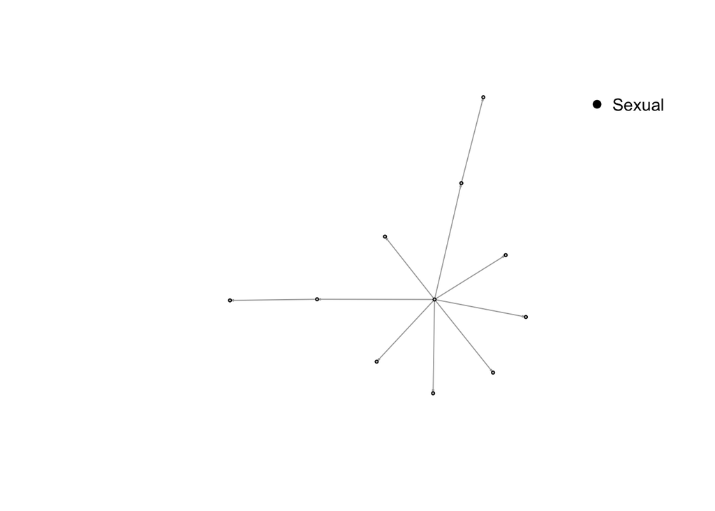

```r
matrix_sexual<- as.matrix(sample_data_sexual)
class(matrix_sexual)<- "character"
graph_sexual<- graph.edgelist(matrix_sexual, directed = T)
plot(graph_sexual, vertex.label = "", vertex.size = 2, vertex.color = "grey", edge.arrow.size = 0.1)
legend("topright", legend = "Sexual", bty = "n", pch = 20, pt.cex = 1.5, cex = 1)
```

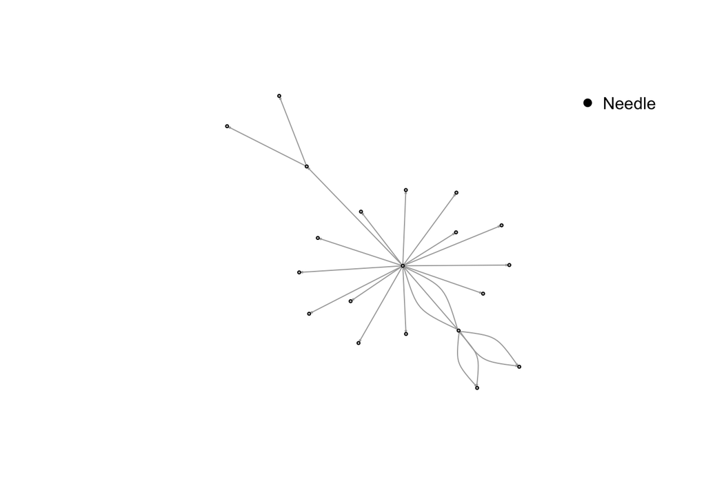

```r
matrix_needle<- as.matrix(sample_data_needle)
class(matrix_needle)<- "character"
graph_needle<- graph.edgelist(matrix_needle, directed = T)
plot(graph_needle, vertex.label = "", vertex.size = 2, vertex.color = "grey", edge.arrow.size = 0.1)
legend("topright", legend = "Needle", bty = "n", pch = 20, pt.cex = 1.5, cex = 1)
```

3.2 Sampled data analysis based on node attribute

3.2.1 Plot the HIV transimssion in various connections (i.e., social, drug, sexual, and needle connections)

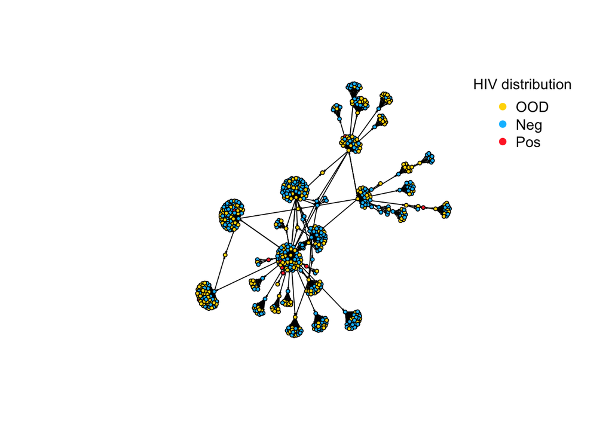

```r
sample_vertex<- as.numeric(V(graph_overall)$name)
sample_node_attribute<- data.frame(node_attribute_data[node_attribute_data$id == sample_seed, ][1,])
for(i in 2:length(sample_vertex))
{
  sample_node_attribute<- rbind(sample_node_attribute, node_attribute_data[node_attribute_data$id == sample_vertex[i], ][1,])
}
sample_node_attribute<- droplevels(sample_node_attribute)

A<- as.matrix(sample_data[1:2])
class(A)<- "character"
V(graph_overall)$race<- as.character(sample_node_attribute$race)
V(graph_overall)$sex<- as.character(sample_node_attribute$sex)
V(graph_overall)$orient<- as.character(sample_node_attribute$orient)
V(graph_overall)$unemp<- as.character(sample_node_attribute$unemp)
V(graph_overall)$streets<- as.character(sample_node_attribute$streets)
V(graph_overall)$educ<- as.character(sample_node_attribute$educ)
V(graph_overall)$hiv<- as.character(sample_node_attribute$hiv)
E(graph_overall)$color<- "black"


plot(graph_overall, vertex.size = 3, vertex.label = '', edge.arrow.size = 0.1, vertex.color = c("firebrick1", "deepskyblue","gold1") [sample_node_attribute$sex])
legend("topright", legend = c("OOD", "Neg", "Pos"), col = c("gold1", "deepskyblue", "firebrick1"), bty = "n", pch = 20, pt.cex = 1.5, cex = 1, title = "HIV distribution")
```

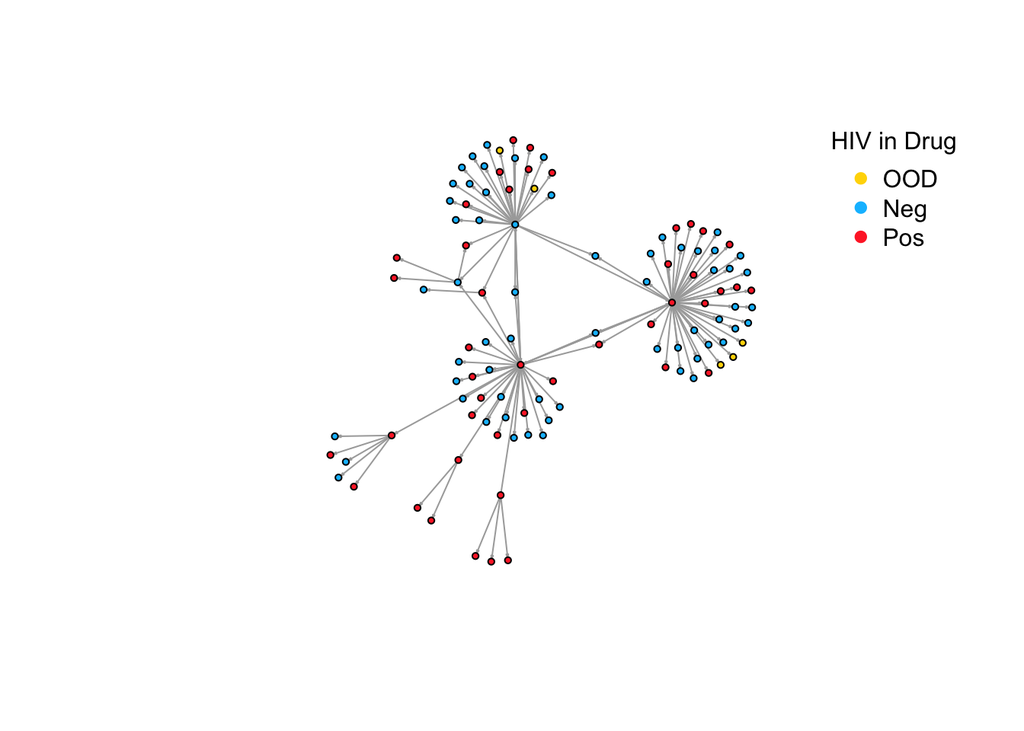

```r
plot(graph_drug, vertex.size = 3, vertex.label = '', edge.arrow.size = 0.1,
     vertex.color = c("gold1", "deepskyblue", "firebrick1") [sample_node_attribute$sex])
legend("topright", legend = c("OOD", "Neg", "Pos"),
       col = c("gold1", "deepskyblue", "firebrick1"),
       bty = "n", pch = 20, pt.cex = 1.5, cex = 1, title = "HIV in Drug")
```

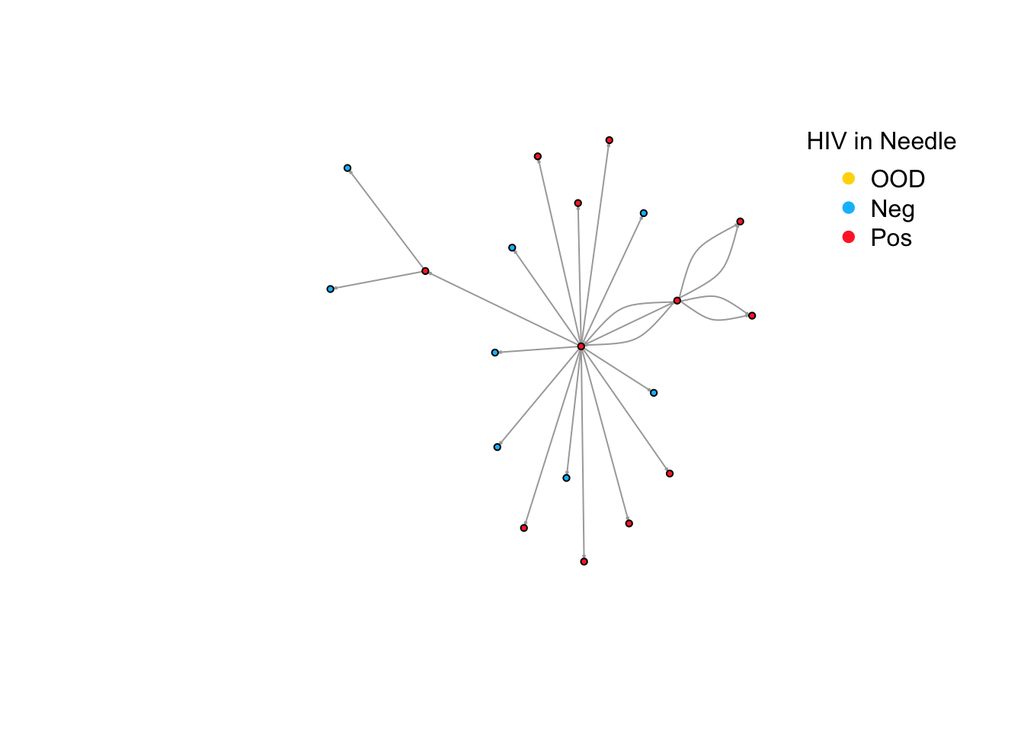

```r
plot(graph_needle, vertex.size = 3, vertex.label = '', edge.arrow.size = 0.1,
     vertex.color = c("gold1", "deepskyblue", "firebrick1") [sample_node_attribute$sex])
legend("topright", legend = c("OOD", "Neg", "Pos"),
       col = c("gold1", "deepskyblue", "firebrick1"),
       bty = "n", pch = 20, pt.cex = 1.5, cex = 1, title = "HIV in Needle")
```

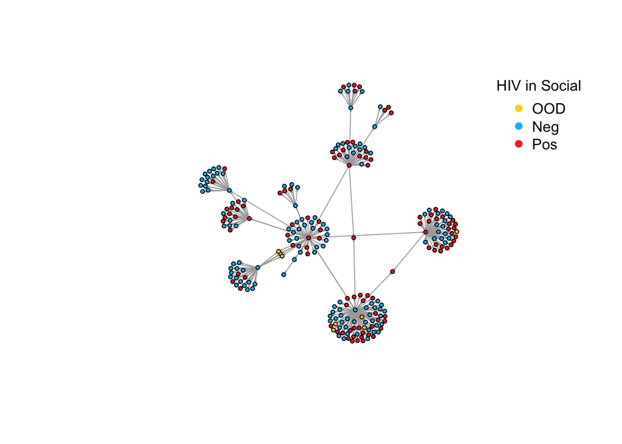

```r
plot(graph_social, vertex.size = 3, vertex.label = '', edge.arrow.size = 0.1,
     vertex.color = c("gold1", "deepskyblue", "firebrick1") [sample_node_attribute$sex])
legend("topright", legend = c("OOD", "Neg", "Pos"),
       col = c("gold1", "deepskyblue", "firebrick1"),
       bty = "n", pch = 20, pt.cex = 1.5, cex = 1, title = "HIV in Social")
```

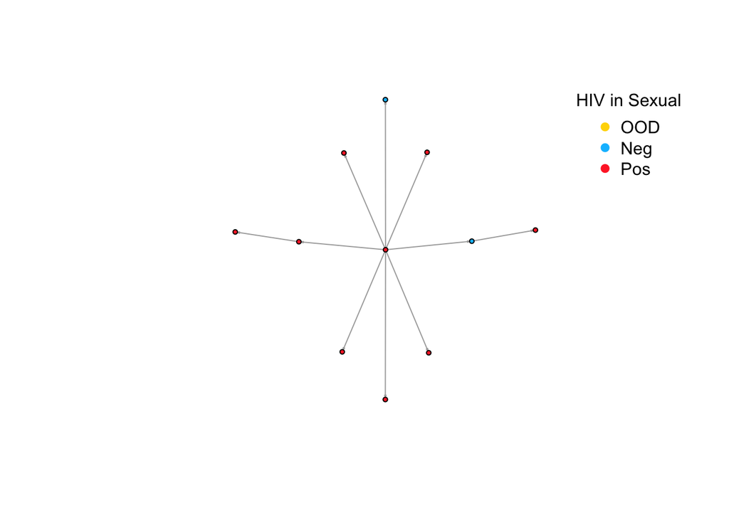

```r
plot(graph_sexual, vertex.size = 3, vertex.label = '', edge.arrow.size = 0.1,
     vertex.color = c("gold1", "deepskyblue", "firebrick1") [sample_node_attribute$sex])
legend("topright", legend = c("OOD", "Neg", "Pos"),
       col = c("gold1", "deepskyblue", "firebrick1"),
       bty = "n", pch = 20, pt.cex = 1.5, cex = 1, title = "HIV in Sexual")
```

3.2.2 Calculate the percentage of HIV in various connections

```r
HIV_total_percentage<- length(DF[DF$hiv1 == "Pos" | DF$hiv2 == "Pos", ]$rid)/length(DF$rid)
HIV_sample_percentage<- length(sample_data[sample_data$hiv1 == "Pos" | sample_data$hiv2 == "Pos", ]$id1)/length(sample_data$id1)

HIV_total_Social_percentage<- length(DF[(DF$hiv1 == "Pos" | DF$hiv2 == "Pos") & DF$tietype == "Social", ]$rid)/length(DF[DF$tietype == "Social",]$rid)
HIV_sample_Social_percentage<- length(sample_data[(sample_data$hiv1 == "Pos" | sample_data$hiv2 == "Pos") & sample_data$edge_type == "Social", ]$id1)/length(sample_data[sample_data$edge_type == "Social",]$id1)

HIV_total_Drug_percentage<- length(DF[(DF$hiv1 == "Pos" | DF$hiv2 == "Pos") & DF$tietype == "Drug", ]$rid)/length(DF[DF$tietype == "Drug",]$rid)
HIV_sample_Drug_percentage<- length(sample_data[(sample_data$hiv1 == "Pos" | sample_data$hiv2 == "Pos") & sample_data$edge_type == "Drug", ]$id1)/length(sample_data[sample_data$edge_type == "Drug",]$id1)

HIV_total_Sexual_percentage<- length(DF[(DF$hiv1 == "Pos" | DF$hiv2 == "Pos") & DF$tietype == "Sexual", ]$rid)/length(DF[DF$tietype == "Sexual",]$rid)
HIV_sample_Sexual_percentage<- length(sample_data[(sample_data$hiv1 == "Pos" | sample_data$hiv2 == "Pos") & sample_data$edge_type == "Sexual", ]$id1)/length(sample_data[sample_data$edge_type == "Sexual",]$id1)

HIV_total_Needle_percentage<- length(DF[(DF$hiv1 == "Pos" | DF$hiv2 == "Pos") & DF$tietype == "Needle", ]$rid)/length(DF[DF$tietype == "Needle",]$rid)
HIV_sample_Needle_percentage<- length(sample_data[(sample_data$hiv1 == "Pos" | sample_data$hiv2 == "Pos") & sample_data$edge_type == "Needle", ]$id1)/length(sample_data[sample_data$edge_type == "Needle",]$id1)

HIV_rate<- data.frame("Total" = c(HIV_total_percentage, HIV_sample_percentage), "Social" = c(HIV_total_Social_percentage, HIV_sample_Social_percentage), "Drug" = c(HIV_total_Drug_percentage, HIV_sample_Drug_percentage), "Sexual" = c(HIV_total_Sexual_percentage, HIV_sample_Sexual_percentage), "Needle" = c(HIV_total_Needle_percentage, HIV_sample_Needle_percentage))
row.names(HIV_rate)<- c("Groundtruth_Data", "Sample_Data")
```

3.3 Calculate the degree, betweenness, and closeness of the network

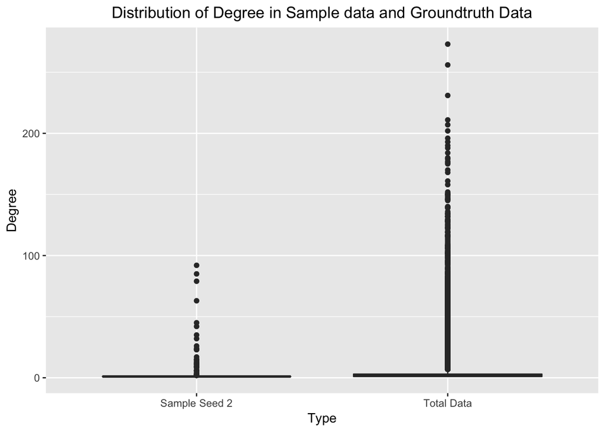

```r
Parameter<- data.frame("Type" = NA, "Degree" = NA, "Betweenness" = NA, "Closeness" = NA)
degree_sample<- as.numeric(degree(graph_overall))
between_sample<- as.numeric(betweenness(graph_overall))
close_sample<- closeness(graph_overall)
for (i in 1:length(degree_sample))
{
  Parameter<- rbind(Parameter, c("Sample Seed 2", as.numeric(degree_sample[i]), as.numeric(between_sample[i]), as.numeric(close_sample[i])))
}

All_data<- as.matrix(DF[,2:3])
class(All_data)<- "character"
degree_all<- as.numeric(degree(graph.edgelist(All_data)))
between_all<- as.numeric(betweenness(graph.edgelist(All_data)))
close_all<- as.numeric(closeness(graph.edgelist(All_data)))
for (i in 1:length(degree_all))
{
  Parameter<- rbind(Parameter, c("Total Data", as.numeric(degree_all[i]), as.numeric((between_all[i]), as.numeric(close_all[i]))))
}

Parameter<- na.omit(Parameter)
class(Parameter$Degree)<- "numeric"
class(Parameter$Betweenness)<- "numeric"
class(Parameter$Closeness)<- "numeric"
box_degree<- ggplot(Parameter, aes(x = Type, y = Degree))
box_degree<- box_degree + geom_boxplot()
#box_degree<- box_degree + scale_x_discrete(labels = x_label)
box_degree<- box_degree + ggtitle("Distribution of Degree in Sample data and Groundtruth Data")
box_degree<- box_degree + theme(plot.title = element_text(hjust = 0.5))
print(box_degree)
```

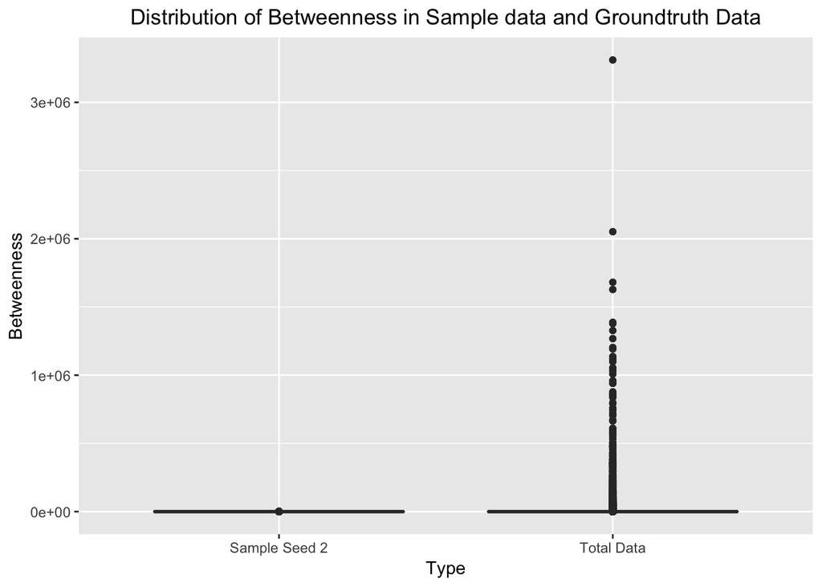

```r
box_between<- ggplot(Parameter, aes(x = Type, y = Betweenness))
box_between<- box_between + geom_boxplot()
#box_degree<- box_degree + scale_x_discrete(labels = x_label)
box_between<- box_between + ggtitle("Distribution of Betweenness in Sample data and Groundtruth Data")
box_between<- box_between + theme(plot.title = element_text(hjust = 0.5))
print(box_between)
```

```r
#plot(table(Parameter[Parameter$Type == "Sample Seed 2",]$Degree))
#plot(table(Parameter[Parameter$Type == "Total Data",]$Degree))

#mean(Parameter[Parameter$Type == "Sample Seed 2",]$Degree)
#mean(Parameter[Parameter$Type == "Total Data",]$Degree)
```